# 3.1 Correlation analysis of PRISM data

##### 6.3.1.1.9 RV_gDR_x_1.11099984921913

🔍 Zoom In for Details

💾 Download Table

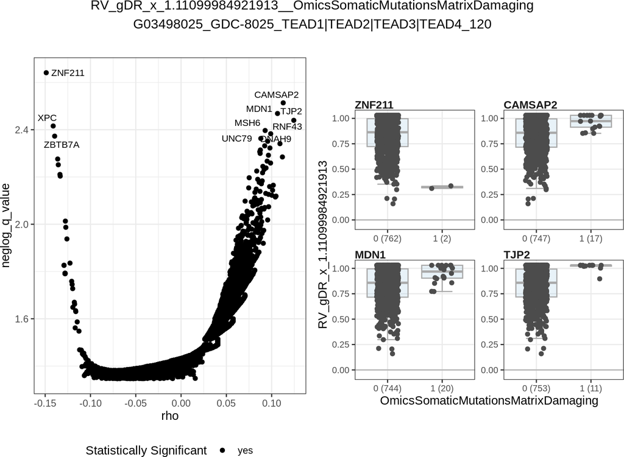

##### 6.3.1.1.10 RV_gDR_x_3.33299759280808

🔍 Zoom In for Details

💾 Download Table

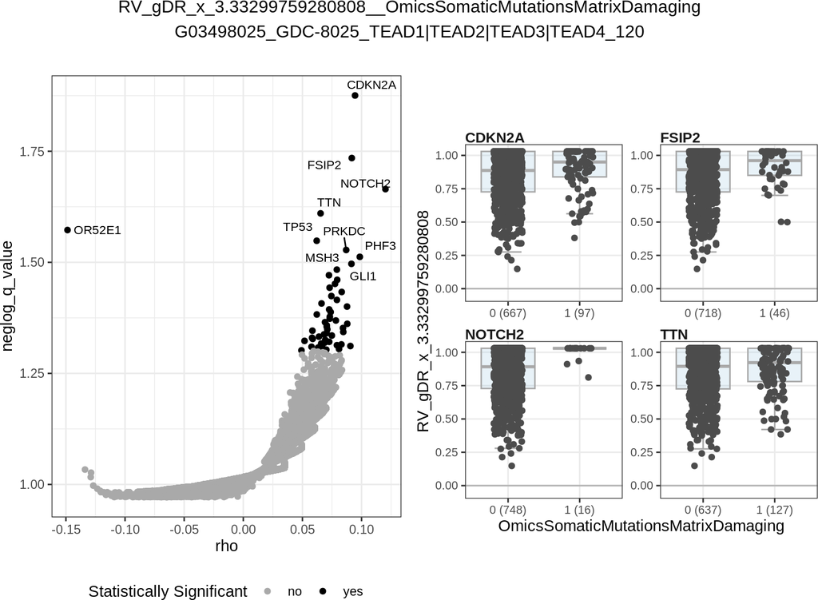

##### 6.3.1.1.11 RV_gDR_x_10

🔍 Zoom In for Details

💾 Download Table

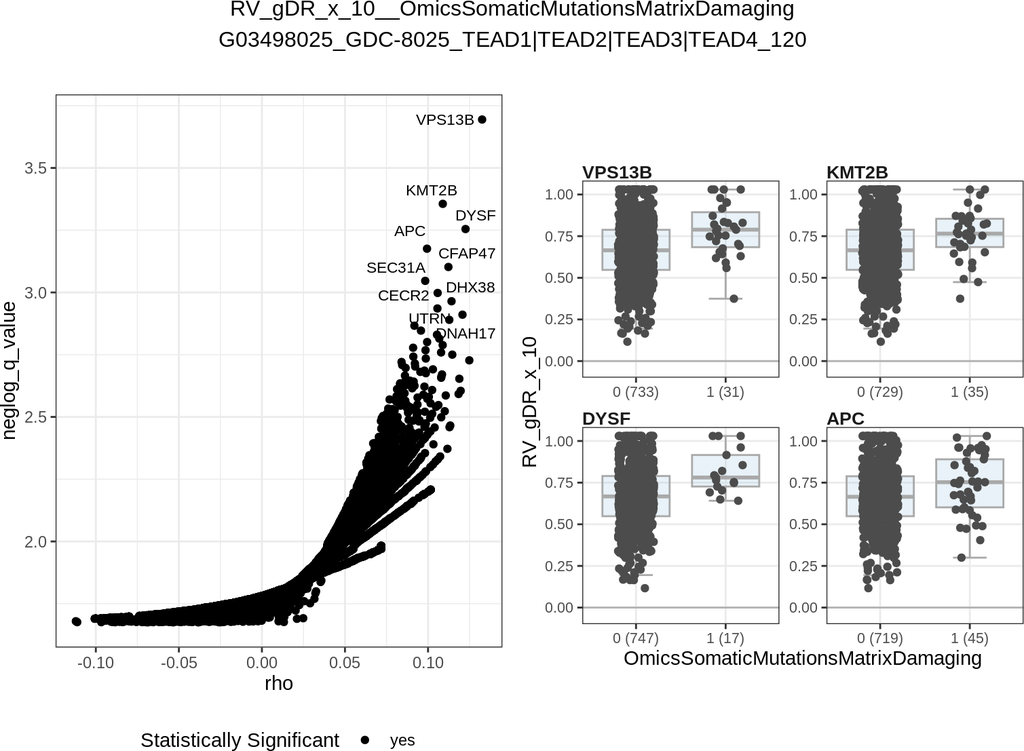

## 6.4 OmicsCNGene

### 6.4.1 GDC-8025

#### 6.4.1.1 Relative Viability

##### 6.4.1.1.1 RV_gDR_x_mean

🔍 Zoom In for Details

💾 Download Table

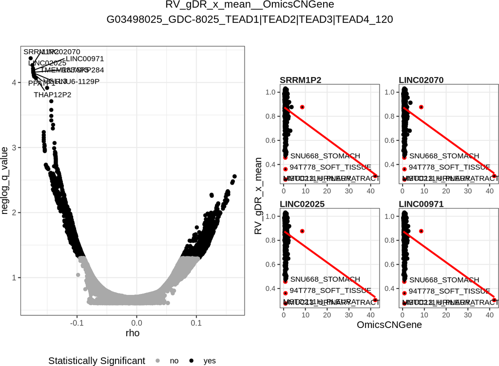

##### 6.4.1.1.2 RV_gDR_log10_xc50

🔍 Zoom In for Details

💾 Download Table

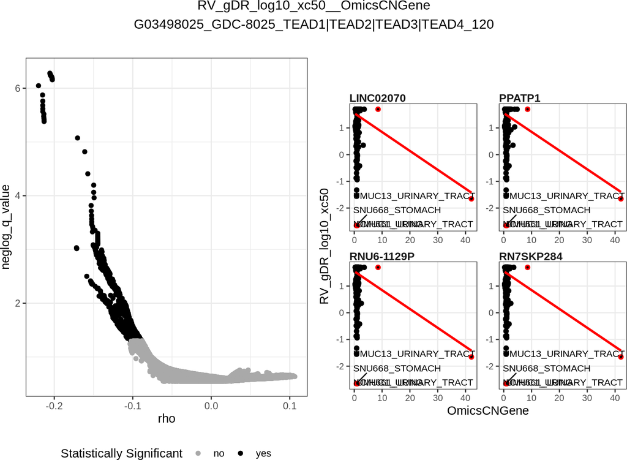

##### 6.4.1.1.3 RV_gDR_x_max

🔍 Zoom In for Details

💾 Download Table

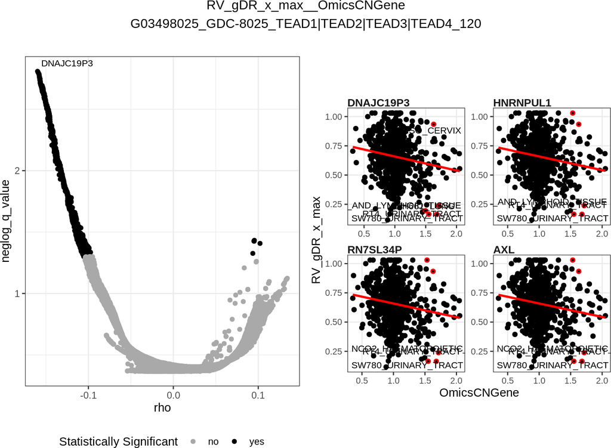

##### 6.4.1.1.4 RV_gDR_x_0.0111099984921913

🔍 Zoom In for Details

💾 Download Table

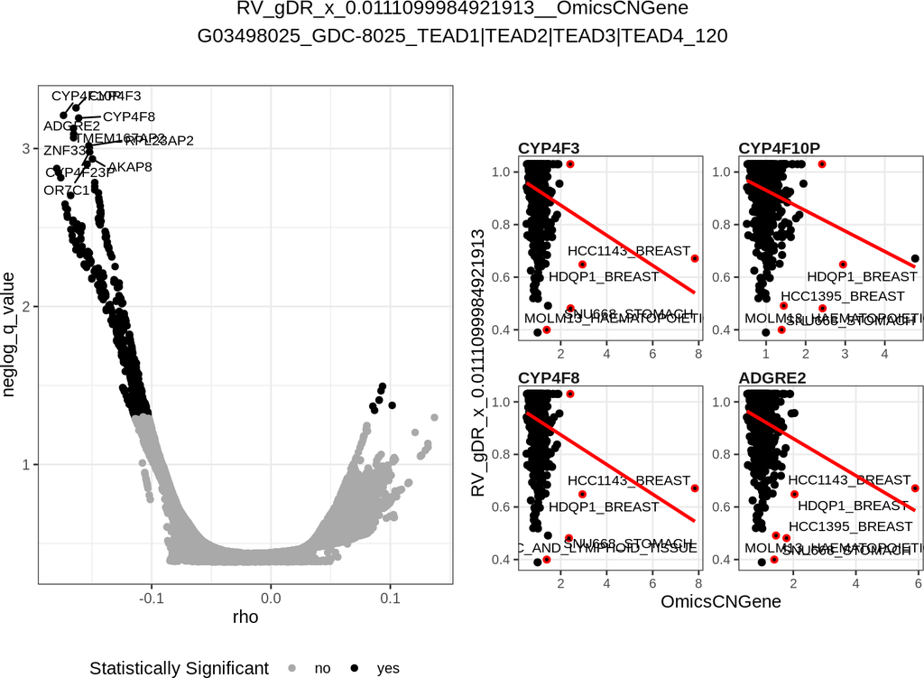

##### 6.4.1.1.5 RV_gDR_x_0.0411500152030233

🔍 Zoom In for Details

💾 Download Table

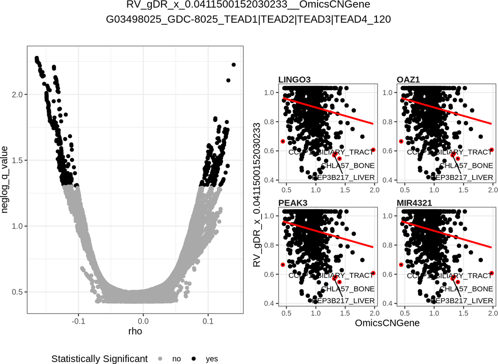

##### 6.4.1.1.6 RV_gDR_x_0.1

🔍 Zoom In for Details

💾 Download Table

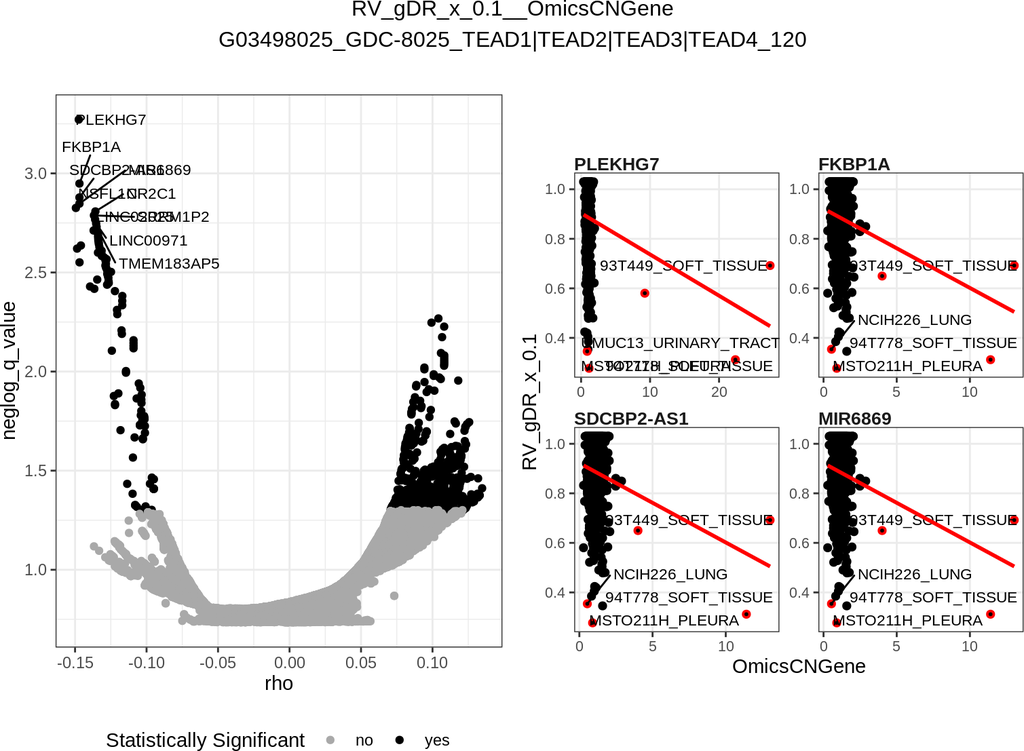

##### 6.4.1.1.7 RV_gDR_x_0.123500012058484

🔍 Zoom In for Details

💾 Download Table

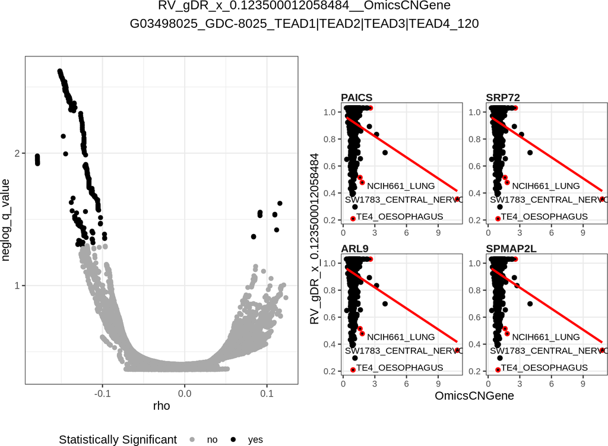

##### 6.4.1.1.8 RV_gDR_x_0.370400018754865

🔍 Zoom In for Details

💾 Download Table

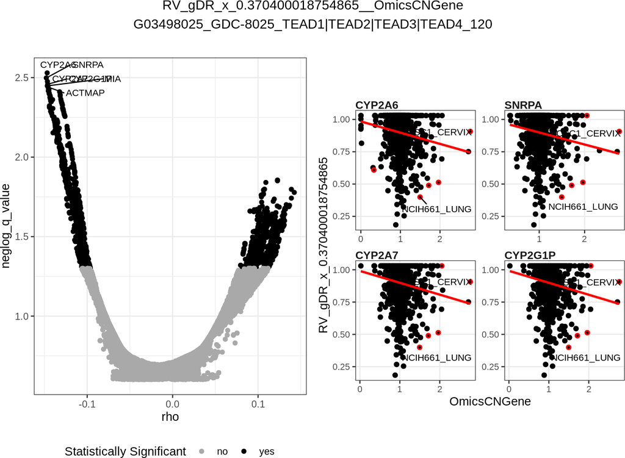

##### 6.4.1.1.9 RV_gDR_x_1.11099984921913

🔍 Zoom In for Details

💾 Download Table

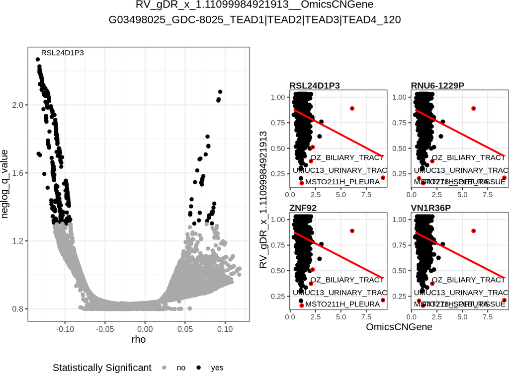

##### 6.4.1.1.10 RV_gDR_x_3.33299759280808

🔍 Zoom In for Details

💾 Download Table

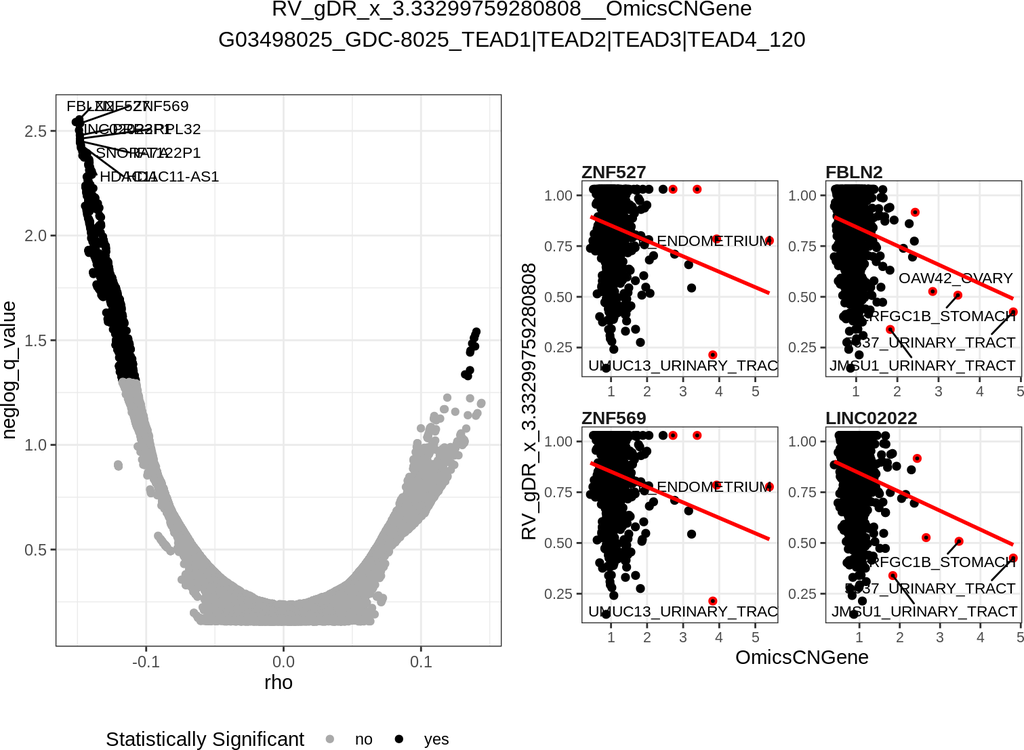

##### 6.4.1.1.11 RV_gDR_x_10

🔍 Zoom In for Details

💾 Download Table

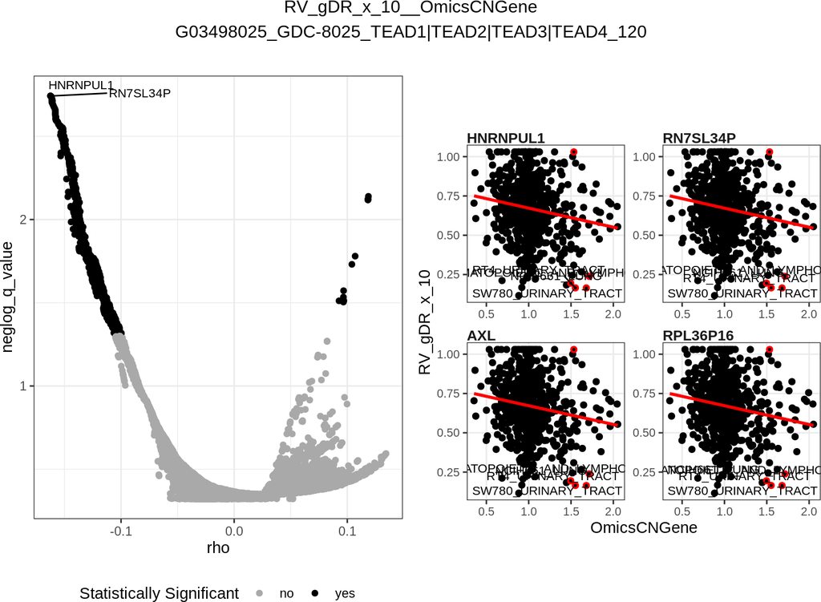

## 6.5 OncotreeLineage

### 6.5.1 GDC-8025

#### 6.5.1.1 Relative Viability

##### 6.5.1.1.1 RV_gDR_x_mean

🔍 Zoom In for Details

💾 Download Table

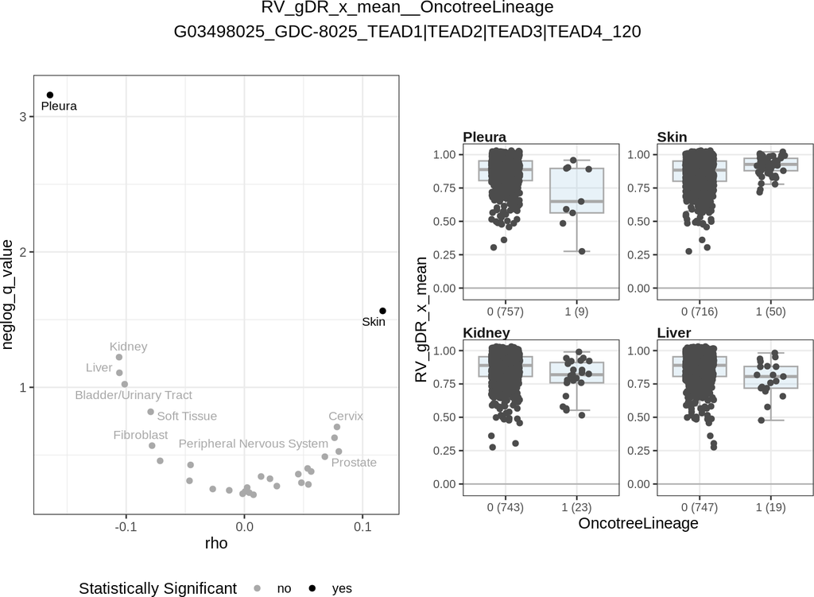

##### 6.5.1.1.2 RV_gDR_log10_xc50

🔍 Zoom In for Details

💾 Download Table

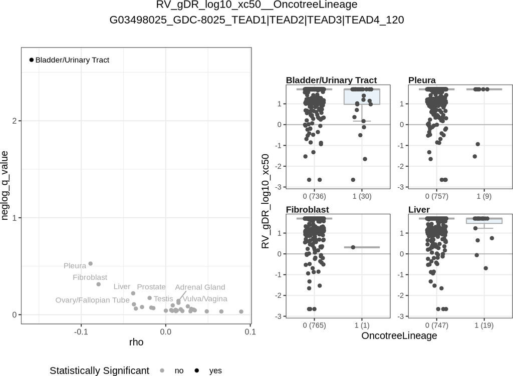

##### 6.5.1.1.3 RV_gDR_x_max

🔍 Zoom In for Details

💾 Download Table

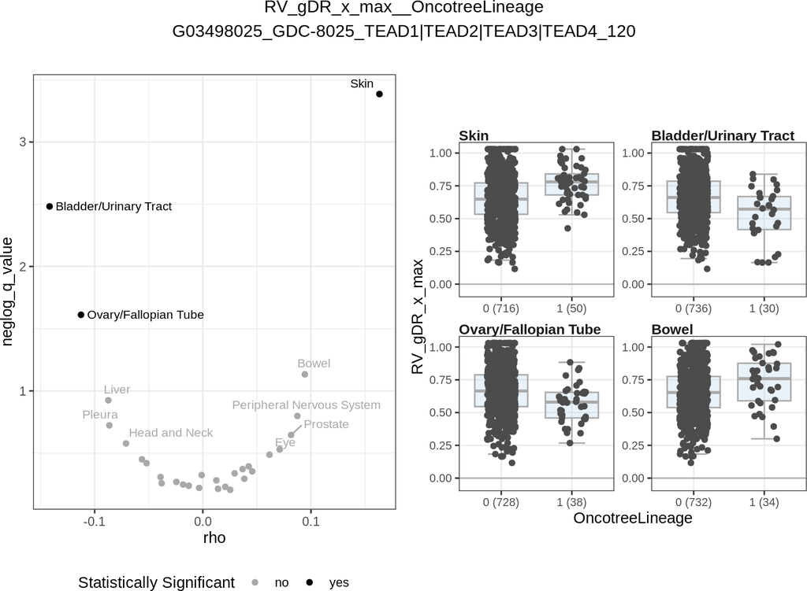

##### 6.5.1.1.4 RV_gDR_x_0.0111099984921913

🔍 Zoom In for Details

💾 Download Table

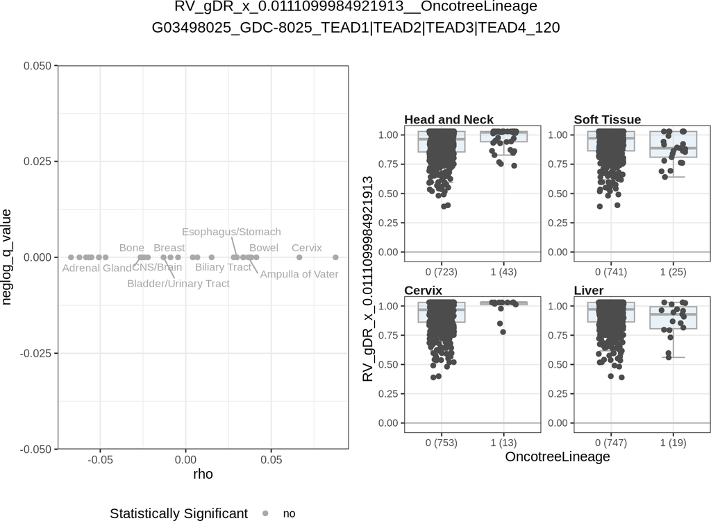

##### 6.5.1.1.5 RV_gDR_x_0.0411500152030233

🔍 Zoom In for Details

💾 Download Table

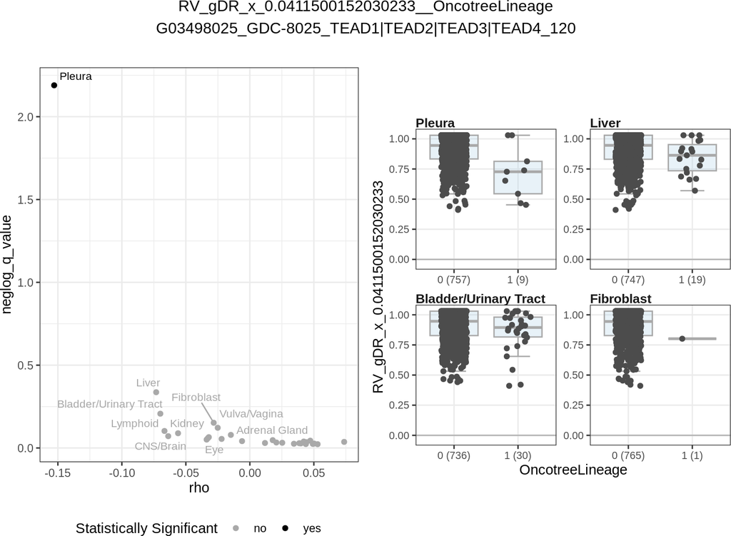

##### 6.5.1.1.6 RV_gDR_x_0.1

🔍 Zoom In for Details

💾 Download Table

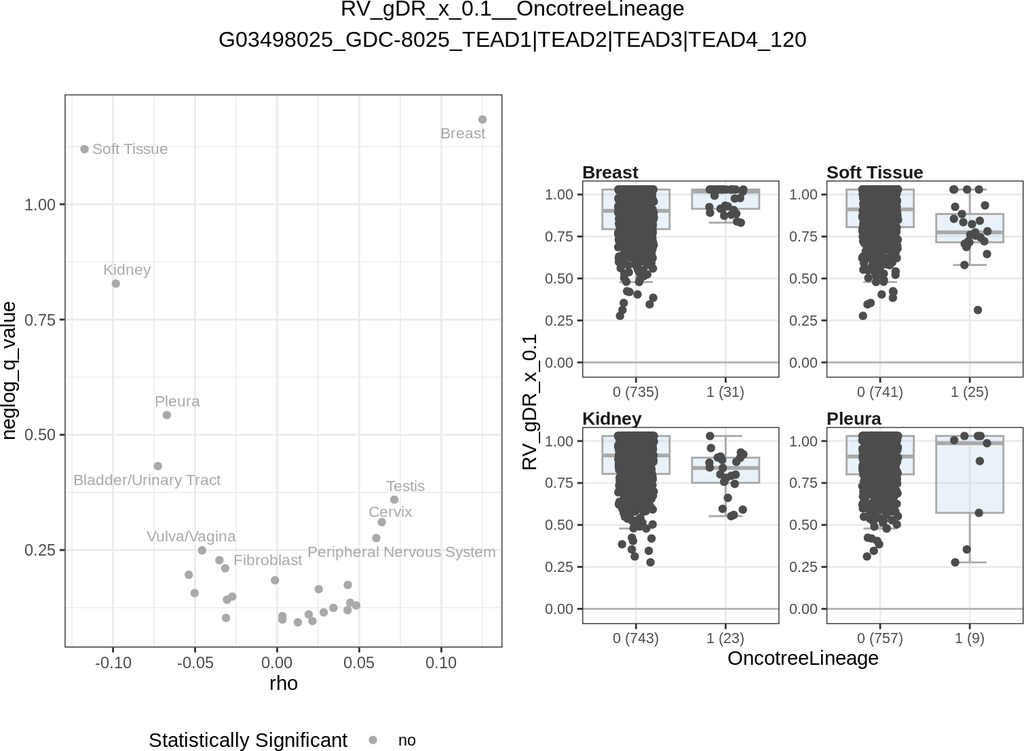

##### 6.5.1.1.7 RV_gDR_x_0.123500012058484

🔍 Zoom In for Details

💾 Download Table

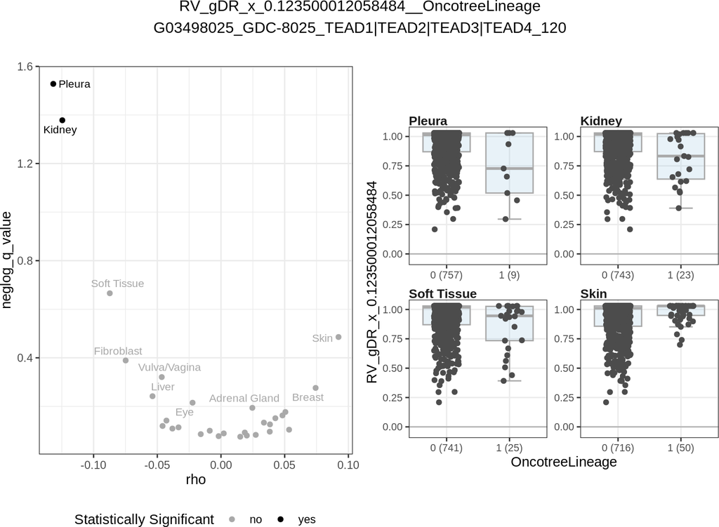

##### 6.5.1.1.8 RV_gDR_x_0.370400018754865

🔍 Zoom In for Details

💾 Download Table

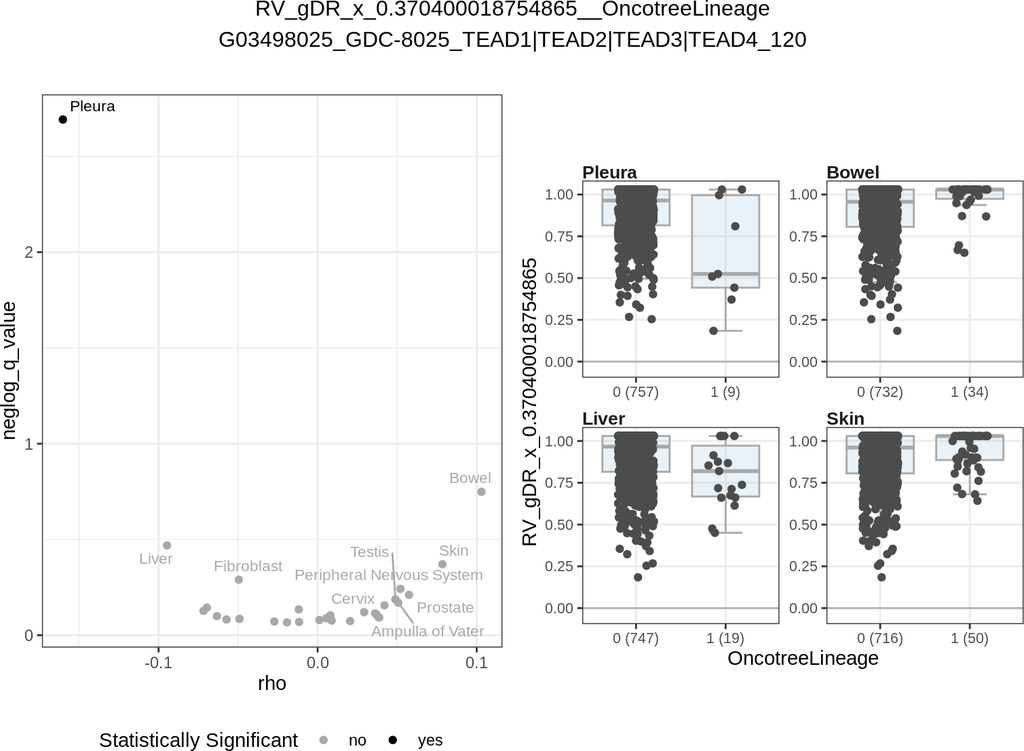

##### 6.5.1.1.9 RV_gDR_x_1.11099984921913

🔍 Zoom In for Details

💾 Download Table

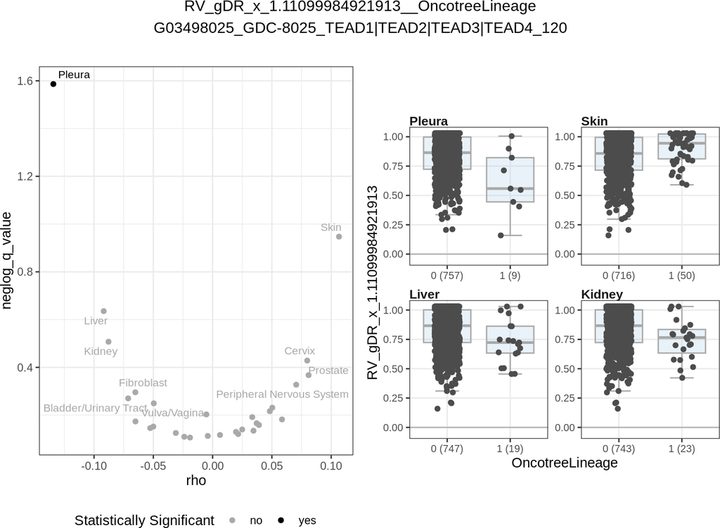

##### 6.5.1.1.10 RV_gDR_x_3.33299759280808

🔍 Zoom In for Details

💾 Download Table

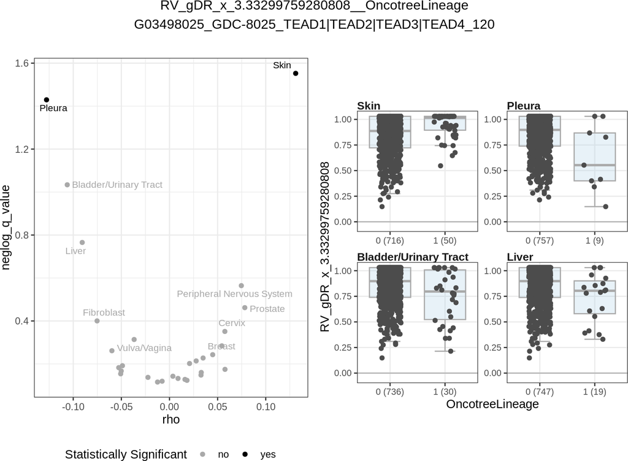

##### 6.5.1.1.11 RV_gDR_x_10

🔍 Zoom In for Details

💾 Download Table

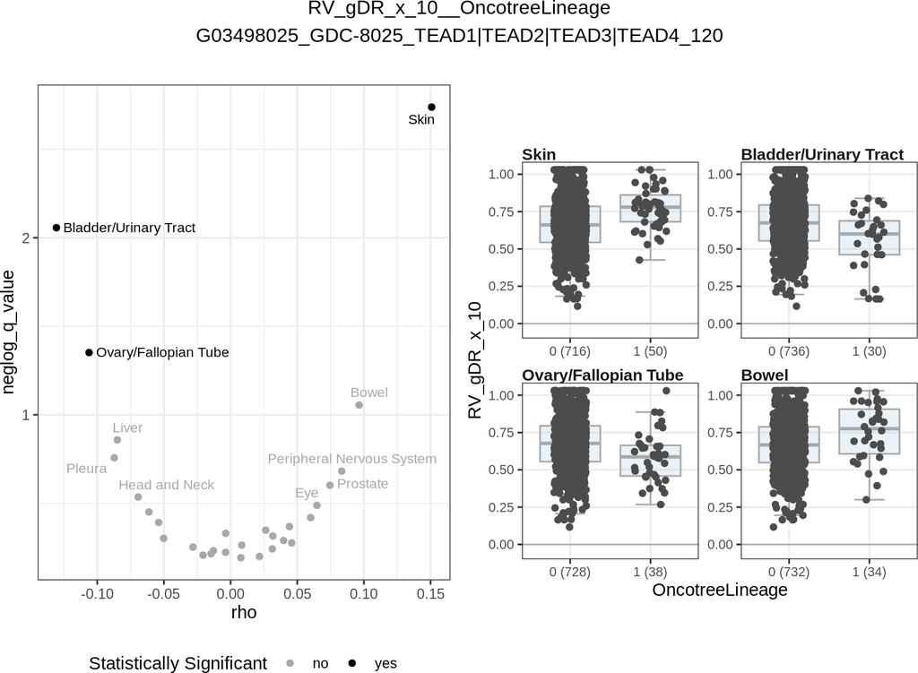

## 6.6 PatientRace

### 6.6.1 GDC-8025

#### 6.6.1.1 Relative Viability

##### 6.6.1.1.1 RV_gDR_x_mean

🔍 Zoom In for Details

💾 Download Table

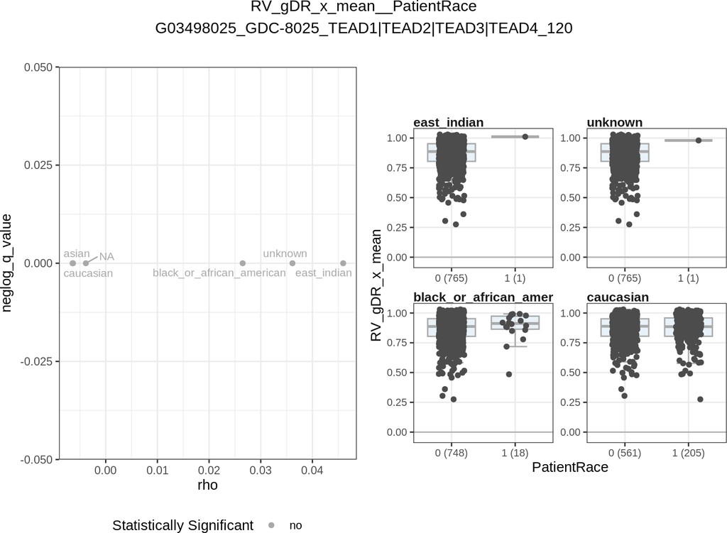

##### 6.6.1.1.2 RV_gDR_log10_xc50

🔍 Zoom In for Details

💾 Download Table

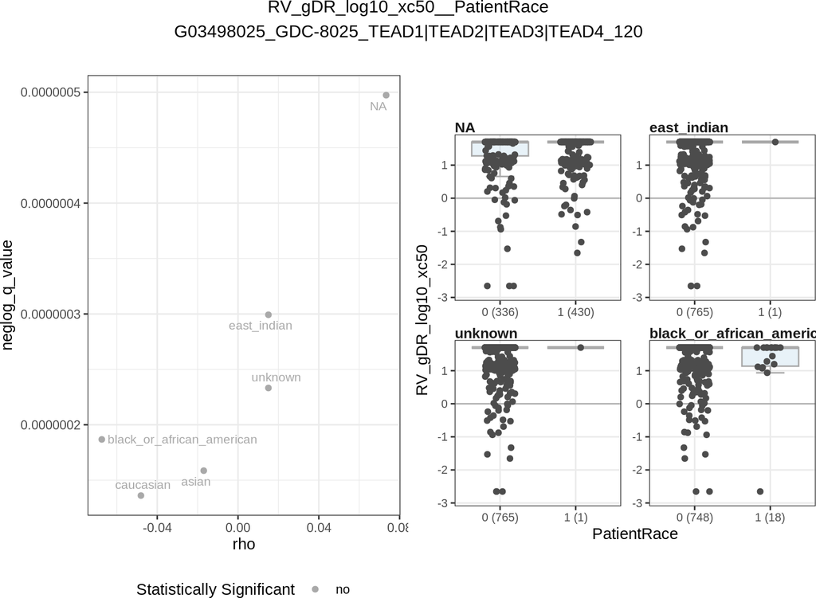

##### 6.6.1.1.3 RV_gDR_x_max

🔍 Zoom In for Details

💾 Download Table

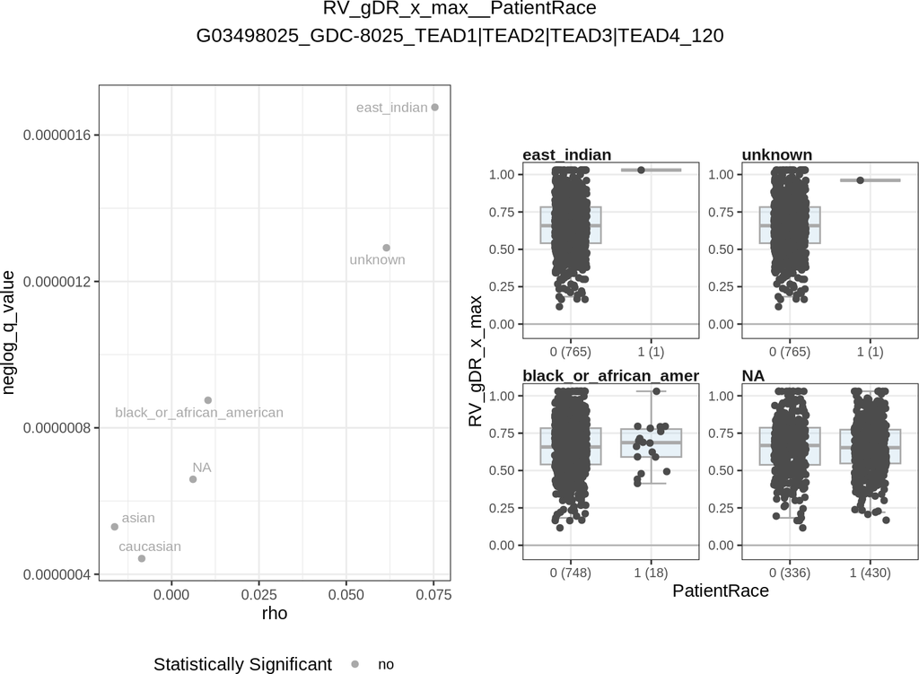

##### 6.6.1.1.4 RV_gDR_x_0.0111099984921913

🔍 Zoom In for Details

💾 Download Table

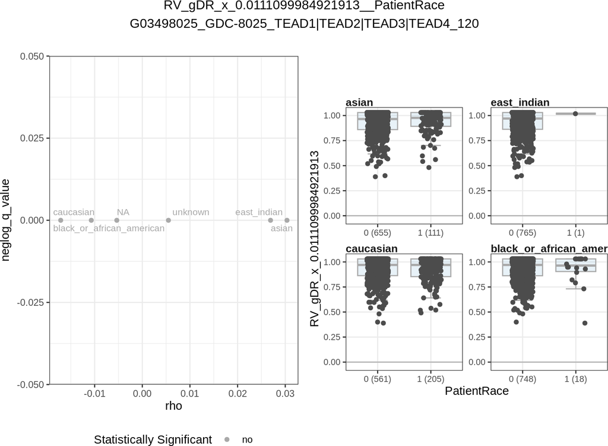

##### 6.6.1.1.5 RV_gDR_x_0.0411500152030233

🔍 Zoom In for Details

💾 Download Table

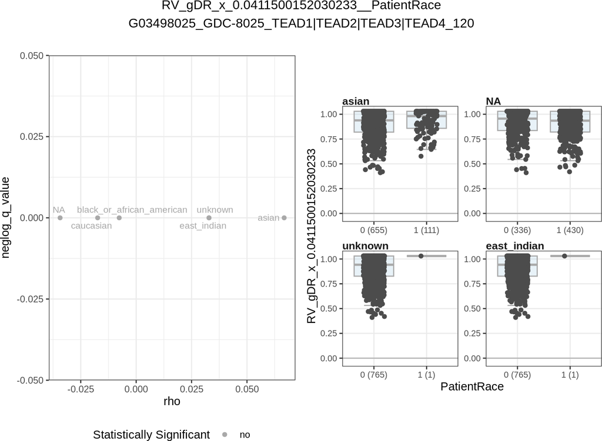

##### 6.6.1.1.6 RV_gDR_x_0.1

🔍 Zoom In for Details

💾 Download Table

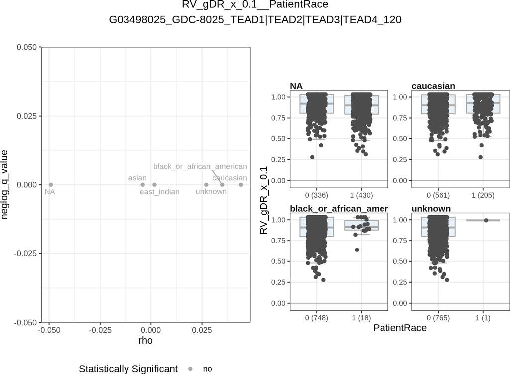

##### 6.6.1.1.7 RV_gDR_x_0.123500012058484

🔍 Zoom In for Details

💾 Download Table

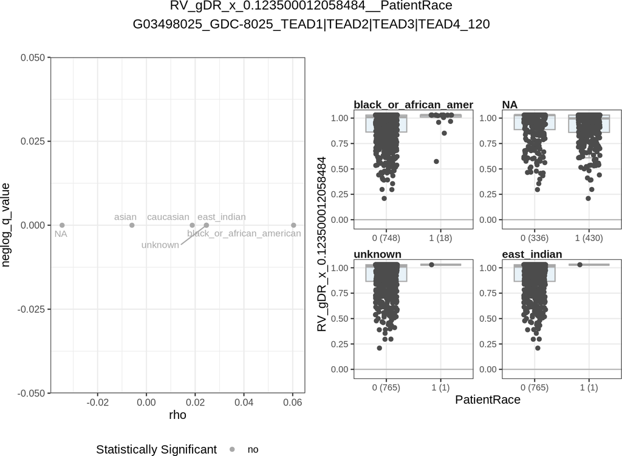

##### 6.6.1.1.8 RV_gDR_x_0.370400018754865

🔍 Zoom In for Details

💾 Download Table

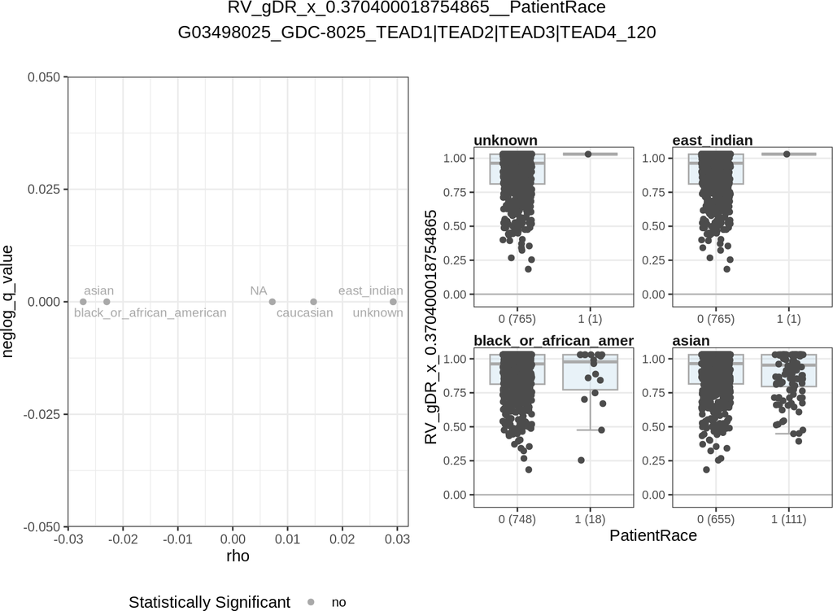

##### 6.6.1.1.9 RV_gDR_x_1.11099984921913

🔍 Zoom In for Details

💾 Download Table

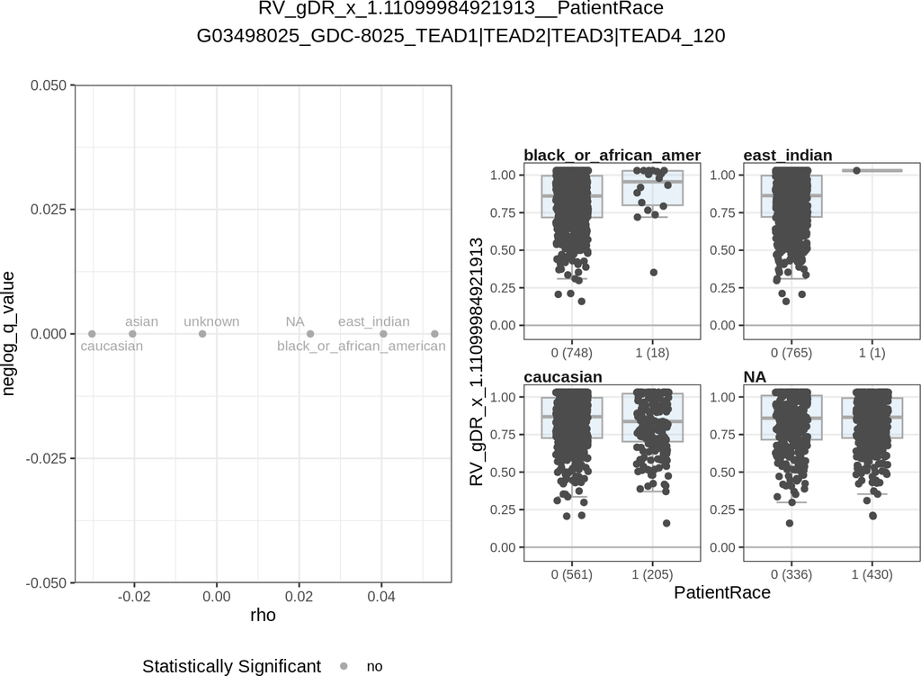

##### 6.6.1.1.10 RV_gDR_x_3.33299759280808

🔍 Zoom In for Details

💾 Download Table

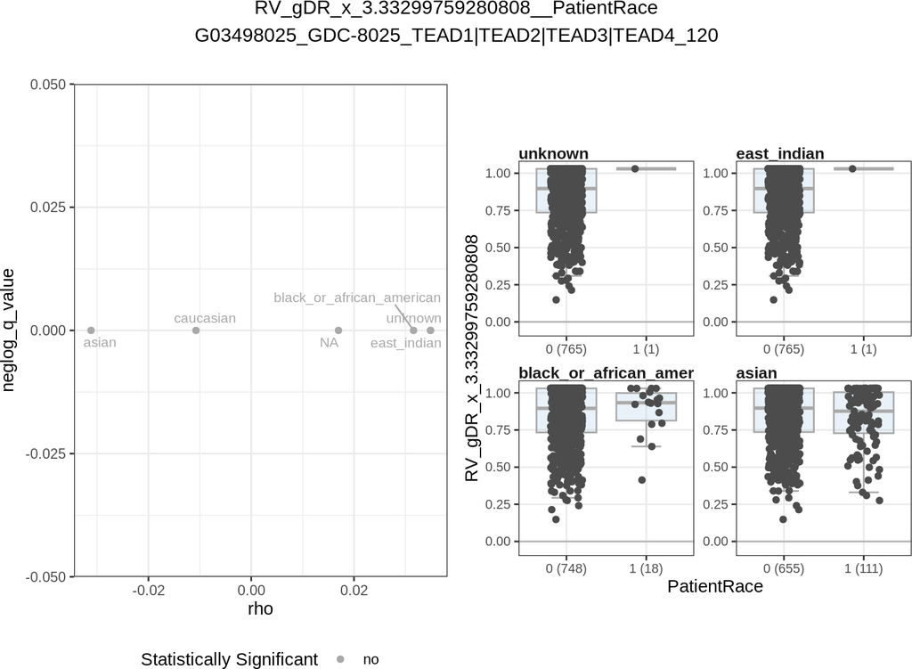

##### 6.6.1.1.11 RV_gDR_x_10

🔍 Zoom In for Details

💾 Download Table

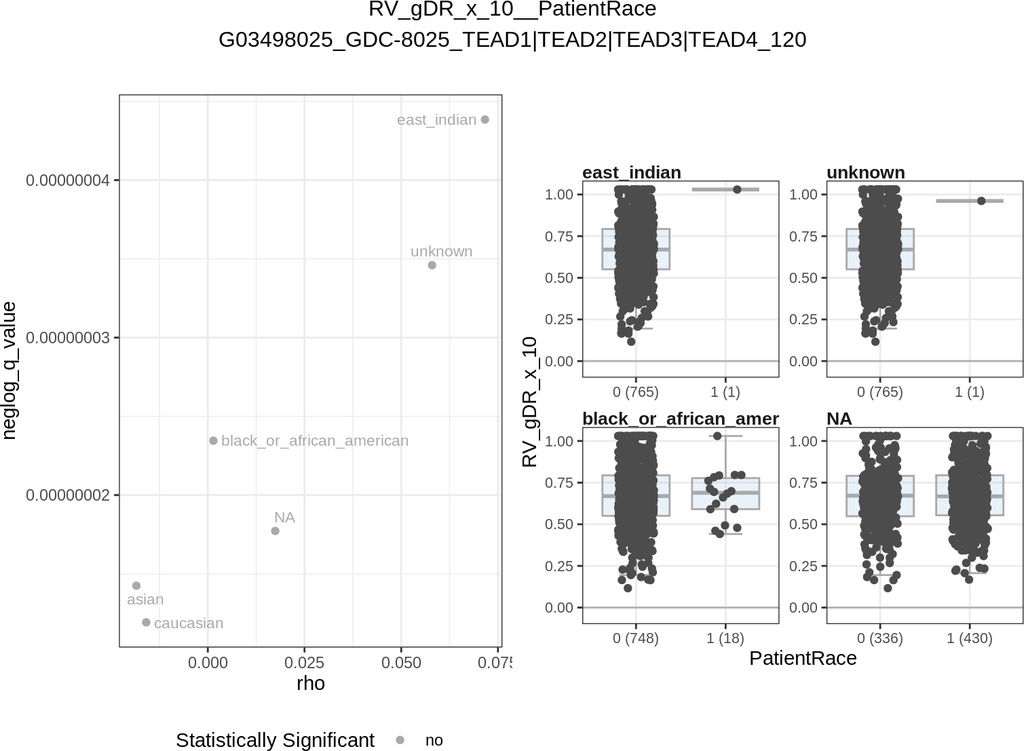

## 6.7 Summary of associations (Single-Agent Data)

The following tables summarize the most statistically significant associations (q-value < 0.05) found across all the analyses for each drug.

**What to look for:**

- Scan the **‘q_value’** column for the lowest values, as these represent the most statistically significant associations.
- Examine the **‘rho’** (correlation coefficient) to understand the direction of the association: a positive value means the feature is associated with resistance (e.g., higher IC50), while a negative value means it’s associated with sensitivity (e.g., lower IC50).
- Note the **‘feature’** and **‘metric’** to understand which specific molecular feature is linked to which drug sensitivity metric.

```r
ls_sa_RV <- list.files(file.path(wd, "tables"), pattern = "sa_depmap_assoc_tab_RV_")
ls_sa_GR <- list.files(file.path(wd, "tables"), pattern = "sa_depmap_assoc_tab_GR_")

alpha <- 0.05
no_of_stat_sign_row <- 10

sa_RV_tab <- prep_assoc_summary(dir_path = file.path(wd, "tables"),
                                ls_file = ls_sa_RV,
                                alpha = alpha,
                                n_stat_sig_row = no_of_stat_sign_row)
sa_GR_tab <- prep_assoc_summary(dir_path = file.path(wd, "tables"),
                                ls_file = ls_sa_GR,
                                alpha = alpha,
                                n_stat_sig_row = no_of_stat_sign_row)

ls_sa_all <- create_PRISM_summary_list(sa_RV_tab, sa_GR_tab)
```

### 6.7.1 GDC-8025

#### 6.7.1.1 Relative Viability

💾 Download Table

|  | feat_meta | feature | response | rho | q_value | neglog_q_value | drug_grid |
| --- | --- | --- | --- | --- | --- | --- | --- |
| 1 | OmicsCNGene | LINC02070 | RV_gDR_log10_xc50 | -0.20559 | 0 | 6.27917 | GDC-8025 |
| 2 | OmicsCNGene | PPATP1 | RV_gDR_log10_xc50 | -0.20526 | 0 | 6.26519 | GDC-8025 |
| 3 | OmicsCNGene | RNU6-1129P | RV_gDR_log10_xc50 | -0.20506 | 0 | 6.25668 | GDC-8025 |
| 4 | OmicsCNGene | RN7SKP284 | RV_gDR_log10_xc50 | -0.20492 | 0 | 6.24982 | GDC-8025 |
| 5 | OmicsCNGene | THAP12P2 | RV_gDR_log10_xc50 | -0.20484 | 0 | 6.24451 | GDC-8025 |
| 6 | OmicsCNGene | CADM2-AS1 | RV_gDR_log10_xc50 | -0.20483 | 0 | 6.24091 | GDC-8025 |
| 7 | OmicsCNGene | VGLL3 | RV_gDR_log10_xc50 | -0.20479 | 0 | 6.23735 | GDC-8025 |
| 8 | OmicsCNGene | SRRM1P2 | RV_gDR_log10_xc50 | -0.2042 | 0 | 6.22921 | GDC-8025 |
| 9 | OmicsCNGene | CADM2 | RV_gDR_log10_xc50 | -0.20336 | 0 | 6.21501 | GDC-8025 |
| 10 | OmicsCNGene | TMEM183AP5 | RV_gDR_log10_xc50 | -0.20302 | 0 | 6.20082 | GDC-8025 |

[output cut: 350 more lines]

# 7 Conclusion

This report has identified potential associations between molecular features and drug sensitivity by correlating the experimental gDR results with data from the DepMap portal. The volcano plots and summary tables highlight the most statistically significant relationships, providing a foundation for biomarker discovery and further mechanistic investigation.

### We Value Your Feedback!

Thank you for using gDR! We are always looking to improve, and your feedback is incredibly valuable to us.

[Share feedback or request features on GitHub](https://github.com/gdrplatform/gDRworkshops/issues)

# 8 gDR session info

```r
gdr_sdt <- get_gDR_session_info()
generate_datatable(gdr_sdt)
```

|  | Package | Version |
| --- | --- | --- |
| 1 | gDRcore | 1.9.7 |
| 2 | gDRimport | 1.9.9 |
| 3 | gDRinternal | 1.0.263 |
| 4 | gDRplots | 0.0.107 |
| 5 | gDRutils | 1.9.8 |
| 6 | gDR | 1.7.2 |
| 7 | gDRcomponents | 1.4.123 |
| 8 | gDRin | 0.2.92 |
| 9 | gDRinternalData | 0.0.13 |
| 10 | gDRinternalShiny | 0.0.21 |

[output cut: 6 more lines]